# Lecture 5 Logistic, Poisson and Negative Binomial Regressions

Eryn McFarlane

2024-10-08

We’re going to simulate some predictor variables for each logistic regression, poisson regression and negative bionomial regression, and then analyze each.

## Logistic Regression

We’re going to have one response variable and two predictor variables (one which is yes or no, the other which is continuous).

### QUESTION: What are you imagining your response variable to be? What are your two predictor variables?

```r
N=1000
predictor_cont<-rnorm(N,0,1)
predictor_binary<-rbinom(N,1,0.5)

y<-1.5*predictor_cont+2.5*predictor_binary+rnorm(N, 0, 0.01) ### Remember that to make this do-able in a linear framework, like this, we're assuming this is on a log scale!

### We're now going to draw a probability distribution from y, assuming that y is on a logit scale

y_prob<-plogis(y)

###Question, tell me about the distribution of y_prob?!

### we can now draw from the probability distribution (so that all of our responses are 0,1)

y_dummy = rbinom(n = N, size = 1, prob = y_prob)


data<-cbind.data.frame(1:N, y_prob, y, predictor_cont, predictor_binary)

log_reg_model<-glm(y_dummy~predictor_binary+predictor_cont, data=data, family='binomial')

### if you have loaded and installed lmerTest, it will give you p-values in your summary, if not, it won't
summary(log_reg_model)
```

```
##
## Call:
## glm(formula = y_dummy ~ predictor_binary + predictor_cont, family = "binomial",
##     data = data)
##
## Coefficients:
##                  Estimate Std. Error z value Pr(>|z|)
## (Intercept)        0.0814     0.1034   0.787    0.431
## predictor_binary   2.2215     0.1898  11.706   <2e-16 ***
## predictor_cont     1.3431     0.1088  12.344   <2e-16 ***
## ---
## Signif. codes:  0 '***' 0.001 '**' 0.01 '*' 0.05 '.' 0.1 ' ' 1
##
## (Dispersion parameter for binomial family taken to be 1)
##
##     Null deviance: 1231.73  on 999  degrees of freedom
## Residual deviance:  875.65  on 997  degrees of freedom
## AIC: 881.65
##
## Number of Fisher Scoring iterations: 5
```

```r
### From here, you need to back transform to get the estimates on the y scale, instead of the log(y) scale

exp(coef(log_reg_model)) ### these are on the 'regular' scale, not the log scale
```

```
##      (Intercept) predictor_binary   predictor_cont
##         1.084807         9.221034         3.830800
```

```r
exp(confint(log_reg_model))
```

```
##                      2.5 %    97.5 %
## (Intercept)      0.8857884  1.329114
## predictor_binary 6.4095504 13.498114
## predictor_cont   3.1136877  4.771997
```

```r
pR2(log_reg_model) ### r2CU (Nagelkerke R2 is the most comparable to our typical R2)
```

```
## fitting null model for pseudo-r2
```

```
##          llh      llhNull           G2     McFadden         r2ML         r2CU
## -437.8253376 -615.8626972  356.0747192    0.2890861    0.2995797    0.4230089
```

### Question: What did you expect the effect sizes of the predictors to be, based on what you simulated (hint, you will need to transform from line 25)?

### Question: The coefficient for predictor_cont is XX (FILL ME IN!) This means that the expected log OR for a one-unit increase in predictor_cont is XX. This means that the OR (biological scale) for a one unit increase in predictor_cont is XX. The R2 for this model is XX. This means that XXXX.

Let’s simulate some Poisson data!

## Poisson Regression

This is mostly borrowed from [Simulate Simulate Simulate 3!](https://aosmith.rbind.io/2018/07/18/simulate-poisson-edition/)

### Question: What is your imagined response variable here? What is your imagined predictor?

### Question: What happens if you add more than one predictor (i.e. x2)?

```r
x1 = rnorm(1000,1,0.1) ### here there is one predictors, this a good place to imagine some biology
summary(x1)
```

```
##    Min. 1st Qu.  Median    Mean 3rd Qu.    Max.
##  0.7065  0.9373  0.9985  1.0003  1.0671  1.3379
```

```r
### Question,

lambda = exp(0.5 + 2.5*x1) ### this is where I change the effect sizes for each predictor

###remember that this means that log(lambda) is a linear model!!
### here I'm simulating three betas against my three predictor variables to make my lambda
### The step above simulates the mean of each value of the response variable. lambda values are continuous, not discrete counts.
## λ is the unobserved true mean of the Poisson distribution for the t-th observation

head(lambda)
```

```
## [1] 28.57943 15.78244 21.41828 27.09512 25.79500 17.62188
```

```r
y = rpois(1000, lambda = lambda) ### error is added in this step, remembering that the mean and the variance are the same!
### remember that y is count data!
head(y)
```

```
## [1] 30 19 26 27 19 18
```

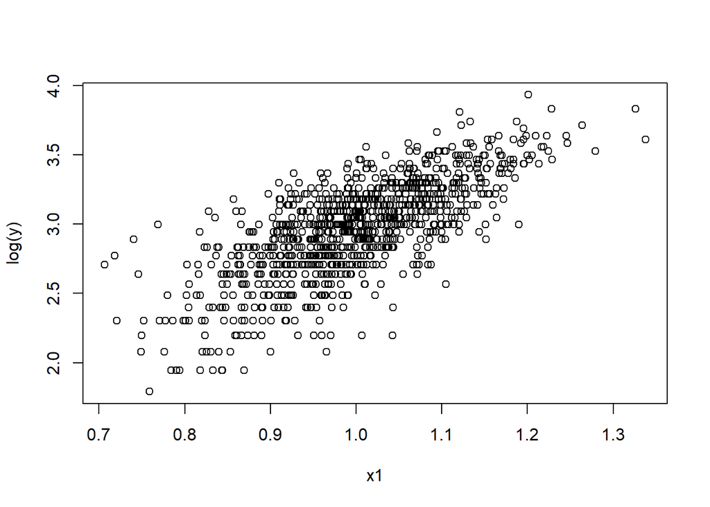

```r
plot(x1, log(y)) ### note the residuals - are they normally distributed? Is that okay?
```

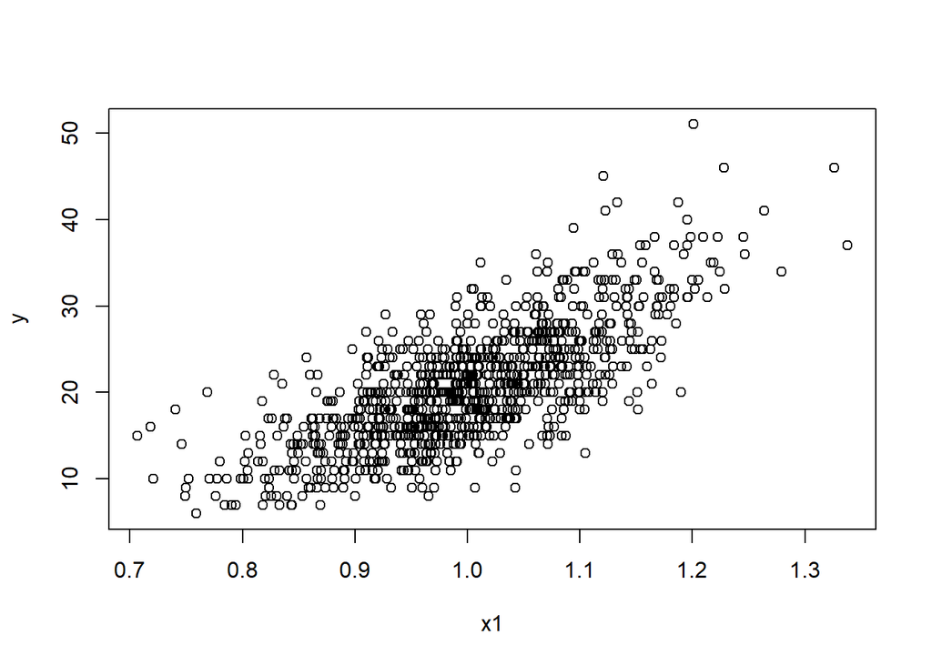

```r
plot(x1,y)
```

```r
data_poisson<-cbind.data.frame(y, x1)

poisson_model<-glm(y ~ x1, family="poisson", data=data_poisson)
summary(poisson_model)
```

```
##
## Call:
## glm(formula = y ~ x1, family = "poisson", data = data_poisson)
##
## Coefficients:
##             Estimate Std. Error z value Pr(>|z|)
## (Intercept)  0.46597    0.07443   6.261 3.83e-10 ***
## x1           2.52926    0.07238  34.943  < 2e-16 ***
## ---
## Signif. codes:  0 '***' 0.001 '**' 0.01 '*' 0.05 '.' 0.1 ' ' 1
##
## (Dispersion parameter for poisson family taken to be 1)
##
##     Null deviance: 2237.7  on 999  degrees of freedom
## Residual deviance: 1019.1  on 998  degrees of freedom
## AIC: 5838.9
##
## Number of Fisher Scoring iterations: 4
```

```r
###back transform the coefficients

exp(coef(poisson_model)) ### these are on the 'regular' scale, not the log scale
```

```
## (Intercept)          x1
##    1.593559   12.544185
```

```r
exp(confint(poisson_model))
```

```
##                2.5 %    97.5 %
## (Intercept)  1.37715  1.843669
## x1          10.88494 14.456057
```

```r
pR2(poisson_model) ### r2CU (Nagelkerke R2 is the most comparable to our typical R2)
```

```
## fitting null model for pseudo-r2
```

```
##           llh       llhNull            G2      McFadden          r2ML
## -2917.4319801 -3526.7393140  1218.6146678     0.1727679     0.7043606
##          r2CU
##     0.7049699
```

### Question: The coefficient for x1 is XX (FILL ME IN!) This means that the expected log count for a one-unit increase in x1 is XX. This means that the count difference (biological scale) for a one unit increase in x1 is XX. The R2 for this model is XX. This means that XXXX.

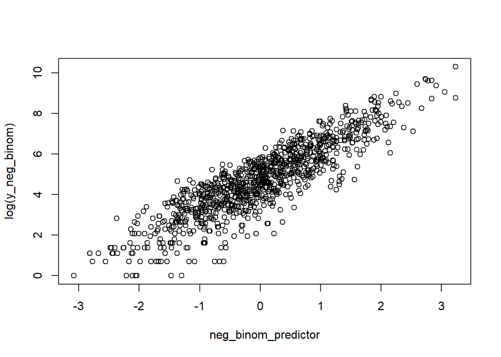

```r
library(MASS)

neg_binom_predictor <- rnorm(1000, mean = 0, sd = 1) ### what is your imagined predictor?


# Log link function: log(mu) = beta0 + beta1 * X


mu <- exp(5+1.5 * neg_binom_predictor) ### notice that this is ALSO on a log scale
### mu is the expected mean for each observation

# Dispersion parameter for the negative binomial distribution
theta <- 2 ### this makes the difference between negative binomial and poisson. A very large theta would lead the negative binomial to approximate a poisson
##Play around with theta and see what happens!


y_neg_binom <- rnegbin(1000, mu = mu, theta = theta)

# Create a data frame to store the simulated data
data_negbiom <- cbind.data.frame(y_neg_binom, neg_binom_predictor)

plot(neg_binom_predictor, log(y_neg_binom))
```

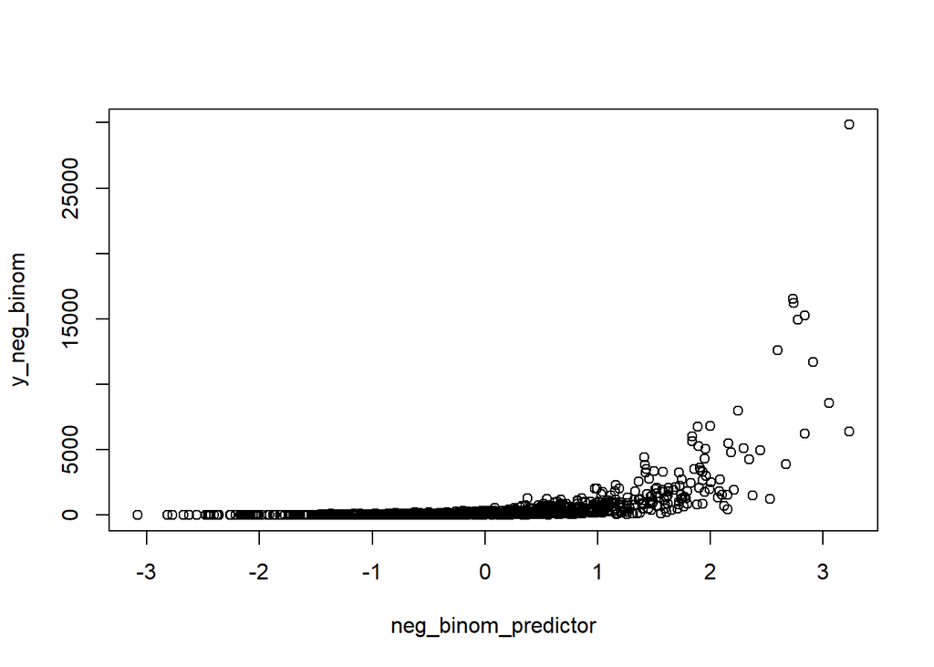

```r
plot(neg_binom_predictor, y_neg_binom)
```

```r
negative_binomial_model<-glm.nb(y_neg_binom ~ neg_binom_predictor, data=data_negbiom)
summary(negative_binomial_model)
```

```
##
## Call:
## glm.nb(formula = y_neg_binom ~ neg_binom_predictor, data = data_negbiom,
##     init.theta = 1.917665527, link = log)
##
## Coefficients:
##                     Estimate Std. Error z value Pr(>|z|)
## (Intercept)          4.99321    0.02326  214.69   <2e-16 ***
## neg_binom_predictor  1.46998    0.02247   65.42   <2e-16 ***
## ---
## Signif. codes:  0 '***' 0.001 '**' 0.01 '*' 0.05 '.' 0.1 ' ' 1
##
## (Dispersion parameter for Negative Binomial(1.9177) family taken to be 1)
##
##     Null deviance: 5924.0  on 999  degrees of freedom
## Residual deviance: 1085.7  on 998  degrees of freedom
## AIC: 11811
##
## Number of Fisher Scoring iterations: 1
##
##
##               Theta:  1.9177
##           Std. Err.:  0.0835
##
##  2 x log-likelihood:  -11805.3290
```

```r
exp(coef(negative_binomial_model)) ### these are on the 'regular' scale, not the log scale
```

```
##         (Intercept) neg_binom_predictor
##          147.408496            4.349142
```

```r
exp(confint(negative_binomial_model))
```

```
##                          2.5 %     97.5 %
## (Intercept)         140.885615 154.332969
## neg_binom_predictor   4.165534   4.542088
```

```r
pR2(negative_binomial_model)
```

```
## fitting null model for pseudo-r2
```

```
##           llh       llhNull            G2      McFadden          r2ML
## -5902.6645105 -6887.8686723  1970.4083237     0.1430347     0.8606001
##          r2CU
##     0.8606010
```

```r
### r2CU (Nagelkerke R2 is the most comparable to our typical R2)
```

### Question: The coefficient for neg_binom_predictor is XX (FILL ME IN!) This means that the expected log count for a one-unit increase in neg_binom_predictor is XX. This means that the count difference (biological scale) for a one unit increase in neg_binom_predictor is XX. The R2 for this model is XX. This means that XXXX.